# Trends in the Automobile Industry

Jacob Park

# Trends in the Automobile Industry

## Data Dictionary

Here is a data dictionary for the cars dataset:

- **year**: a character variable that states the first year of each generation.
- **make**: a character variable that states the brand of the vehicle
- **model**: a character variable that states the model of the vehicle. For cars with a general class of vehicle, the common name will be used. For example: BMW 3 class will be just “3”.
- **displacement**: a numerical variable that states the vehicle engine’s displacement. This figure is in liters.
- **hp**: a numerical variable that states the vehicle’s horsepower rating. This is the stated horsepower from the manufacturer and not user-reported.
- **mpg**: a numerical variable that states the average miles per gallon for each vehicle.
- **turbo**: a categorical variable that states whether the car is turbo charged or naturally aspirated. “Yes” is turbo charged and “No” is naturally aspirated. The choices are:
  - yes
  - no
- **gas_price**: a numerical variable that states the average gas price across the nation for the year. This figure is from a government website: “https://www.energy.gov”

Which can be read in as follows:

```r
cars <- read_csv("https://raw.githubusercontent.com/urstats/stat209-s18-jacobpaark/master/data.csv")
```

## Exploratory Analysis

The main trend that can be seen is as the years go by and the technology improves, horsepower has a steady increase. The size of the points on the graph increases with the displacement, which implies a positive correlation between engine size and horsepower. There is also a small trend towards manufacturers implementing turbocharged engines for certain manufacturers like Honda and Volkswagen for this generation in an effort to increase fuel economy.

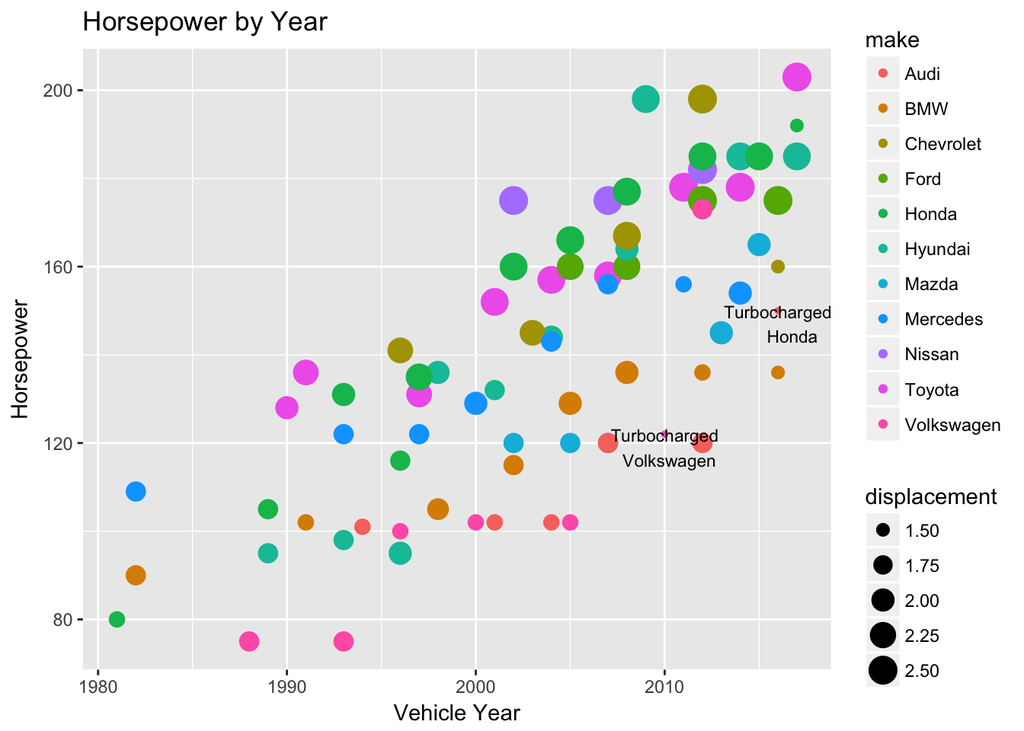

However, there does not seem to be a strong correlation between engine size and fuel economy. The main correlation is as the cars get newer and technology improves, fuel economy improves as a result. There are also other intitiatives and technology that manufacturers are implementing into their engines like Honda’s VVT-i technology and Mazda’s skyactiv technology to improve their fuel economy without moving to a turbocharged engine (Mazda). There are couple reason why manufacturers are reluctant to move to a turbocharged engine. The reasons are: it can be costly to repair, less reliable, less horsepower, require more expensive premium gas, and costly research and development (Explained). However, major companies like Honda and Volkswagen are already making the leap to futureproof their engines.

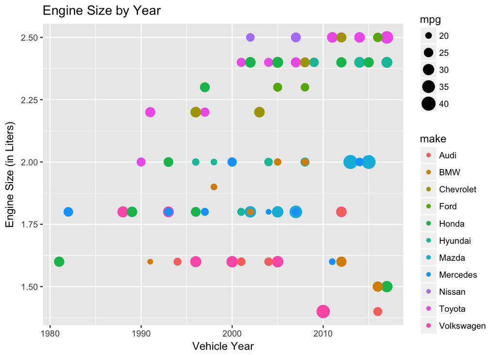

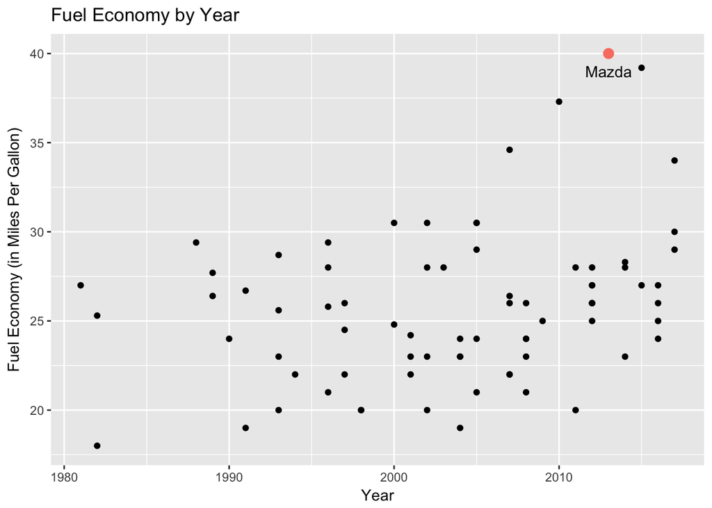

Another interesting trend was the increase in fuel economy as gas prices increased. There is a clump of vehicles in between the 20-30 MPG range when the average gas prices are low. As the gas price increase, there are manufacturers that increase their fuel economy to over 30 MPG to entice buyers with their affordability.

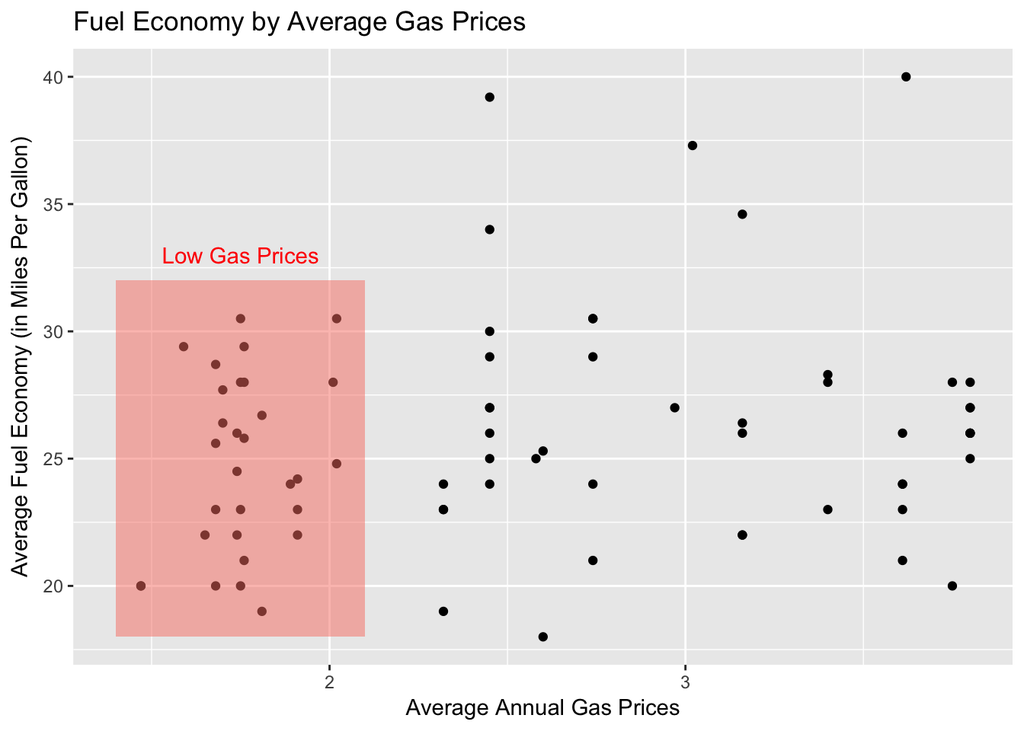

## Conclusion

This research outlines many different interesting trends that occur in the automobile industry. There has been a strong increase in horsepower as the years go by to compete with their competitors. However, there was not a strong correlation between engine size and fuel economy because of the technology that is being implemented to increase fuel economy without moving to a lower displacement engine. Another interesting fact was the increase of fuel economy as the gas price rise. Since the government is mandating an average of 50.5 mpg for their vehicle lineups, manufacturers are pushing to get their vehicles to be more fuel efficient.

## References

Explained, Engineering. “Engineering Explained: The Pros And Cons Of Turbochargers Vs Superchargers.” Car Throttle, Car Throttle, 18 May 2015, www.carthrottle.com/post/engineering-explained-the-pros-and-cons-of-turbochargers-vs-superchargers/.

“Find and Compare Cars.” Www.fueleconomy.gov - the Official Government Source for Fuel Economy Information, www.fueleconomy.gov/feg/findacar.shtml.

MAZDA: SKYACTIV TECHNOLOGY | Technology, www.mazda.com/en/innovation/technology/skyactiv/.

Shepardson, David. “EPA Locks in 2025 Fuel Efficiency Rules.” Reuters, Thomson Reuters, 13 Jan. 2017, www.reuters.com/article/us-usa-automakers/epa-locks-in-2025-fuel-efficiency-rules-idUSKBN14X1Q6.

“Vehicle Technologies Office.” Department of Energy, energy.gov/eere/vehicles/vehicle-technologies-office.

“VTEC vs VVT-i.” VTEC vs VVT-i - Difference and Comparison | Diffen, www.diffen.com/difference/VTEC_vs_VVT-i.